# TensorFlow_Tutorial

**Resources:**  
https://www.matroid.com/dlwithtf/chap1-2.pdf  
https://cs224d.stanford.edu/lectures/CS224d-Lecture7.pdf  
http://rail.eecs.berkeley.edu/deeprlcourse/static/slides/lec-3.pdf  
https://www.tensorflow.org/learn

## TensorFlow Tutorial

A tensor is simply an array of numbers. It’s often convenient to view a tensor as a function instead. The most common definition introduces a tensor as a multilinear function from a product of vector spaces to the real numbers.

$T: V_1 \times V_2 \times ... V_n \rightarrow R$

A multilinear function is simply a function which is linear in each argument. This function can be viewed as assigning individual entries of a multidimensional array, when provided indices into the array as arguments.

TensorFlow is a library for defining computation graphs and calculating gradients.

[figure not shown]

### Packages

```python
import tensorflow as tf
import numpy as np
import matplotlib.pyplot as plt
import matplotlib.cm as cm
import matplotlib.patches as mpatches
import seaborn
```

When experimenting with Tensorflow interactively, it’s convenient to use `tf.InteractiveSession()`. Invoking this statement within IPython will make Tensorflow behave almost imperatively, allowing beginners to play with tensors much more easily.

```python
tf.InteractiveSession()
```

```
<tensorflow.python.client.session.InteractiveSession at 0x1a1c9eb4e0>
```

```python
a = tf.zeros((2,2))
b = tf.ones((2,2))
```

`TensorShape` behaves like a python tuple.

```python
b.get_shape()
```

```
TensorShape([Dimension(2), Dimension(2)])
```

TensorFlow computations define a computation graph that has no numerical value until evaluated!

```python
print(a)
```

```
Tensor("zeros:0", shape=(2, 2), dtype=float32)
```

```python
print(a.eval())
```

```
[[0. 0.]
 [0. 0.]]
```

```python
tf.reduce_sum(b,reduction_indices=[1])
```

```
<tf.Tensor 'Sum:0' shape=(2,) dtype=float32>
```

```python
tf.reduce_sum(b,reduction_indices=[1]).eval()
```

```
array([2., 2.], dtype=float32)
```

A `Session` object encapsulates the environment in which Tensor objects are evaluated.

```python
a = tf.constant(4.)
b = tf.constant(7.)
c = a * b
with tf.Session() as sess:
    print(sess.run(c))
    print(c.eval())
```

```
28.0
28.0
```

`c.eval()` is just syntactic sugar for `sess.run(c)` in the currently active session!  
`tf.InteractiveSession()` is just convenient syntactic sugar for keeping a default session open in ipython.  
`sess.run(c)` is an example of a TensorFlow Fetch.

`TensorFlow` programs are usually structured into a **construction phase**, that assembles a **graph**, and an **execution phase** that uses a **session** to execute ops in the graph. All computations add nodes to global default graph.

When you train a model you use variables to hold and update parameters. Variables are in-memory buffers containing tensors. TensorFlow variables must be **initialized** before they have values! Contrast with constant tensors.

```python
W1 = tf.ones((2,2))
W2 = tf.Variable(tf.zeros((2,2)), name = 'weights')
with tf.Session() as sess:
    print(sess.run(W1))
    sess.run(tf.global_variables_initializer())
    print(sess.run(W2))
```

```
[[1. 1.]
 [1. 1.]]
[[0. 0.]
 [0. 0.]]
```

Variable objects can be initialized from constants or random values.

```python
W = tf.Variable(tf.zeros((2,2)), name = 'weights')
R = tf.Variable(tf.random_normal((2,2)), name = 'random_weights')
with tf.Session() as sess:
    sess.run(tf.global_variables_initializer())
    print(sess.run(W))
    print(sess.run(R))
```

```
[[0. 0.]
 [0. 0.]]
[[-0.5052257  -1.5077016 ]
 [ 0.15038973  0.32715705]]
```

Updating Variables:

```python
state = tf.Variable(0, name = 'counter')
new_value = tf.add(state, tf.constant(1))
update = tf.assign(state, new_value)
with tf.Session() as sess:
    sess.run(tf.global_variables_initializer())
    print(sess.run(state))
    for _ in range(3):
        sess.run(update)
        print(sess.run(state))
```

```
0
1
2
3
```

Calling `sess.run(var)` on a `tf.Session()` object retrieves its value. Can retrieve multiple variables simultaneously with `sess.run([var1, var2])`.

```python
input_1 = tf.constant(3.)
input_2 = tf.constant(5.)
input_3 = tf.constant(4.)
intermed = tf.add(input_2, input_3)
mul = tf.multiply(intermed, input_1)
with tf.Session() as sess:
    print(sess.run([intermed, mul]))
```

```
[9.0, 27.0]
```

We can input external data into `TensorFlow` using `Numpy`:

```python
a = np.zeros((3,3))
tf_a = tf.convert_to_tensor(a)
with tf.Session() as sess:
    print(sess.run(tf_a))
```

```
[[0. 0. 0.]
 [0. 0. 0.]
 [0. 0. 0.]]
```

Inputting data with `tf.convert_to_tensor()` cannot be scaled. `tf.placeholder` variables which are dummy nodes that provide entry points for data to computational graph can be used. A `feed_dict` is a python dictionary mapping from `tf.placeholder` vars (or their names) to data (numpy arrays, lists, ...).

```python
# Define tf.placeholder objects for data entry.
input_1 = tf.placeholder(tf.float32)
input_2 = tf.placeholder(tf.float32)
output = tf.multiply(input_1, input_2)
# Fetch value of output from computation graph.
# Feed data into computation graph
with tf.Session() as sess:
    print(sess.run([output], feed_dict = {input_1 : [7.], input_2 : [8.]}))
```

```
[array([56.], dtype=float32)]
```

Complicated TensorFlow models can have hundreds of variables. `tf.variable_scope()` provides simple name-spacing to avoid clashes. `tf.get_variable()` creates/accesses variables from within a variable scope. The variable naming inside a scope is analogous to the directory structure. We can also have nested scopes.

```python
with tf.variable_scope('scope_1'):
    var = tf.get_variable('variable1', [1])
print(var.name)
```

```
scope_1/variable1:0
```

```python
with tf.variable_scope('scope_1'):
    # creating a nested scope
    with tf.variable_scope('scope_2'):
        var = tf.get_variable('variable2', [1])
print(var.name)
```

```
scope_1/scope_2/variable2:0
```

`variable_scope` controls variable (re)use. For example if we want to share the weight variable between layers of a recurrent neural network then we can say that we are reusing the same weight variable for different layers.

```python
with tf.variable_scope('scope_1'):
    var = tf.get_variable('variable10', [1])
    tf.get_variable_scope().reuse_variables()
    var2 = tf.get_variable('variable10', [1])
assert var == var2
```

If `reuse` set to be `False` (which is the default value), `get_variable` creates and returns new variable. If `reuse` set to be `True`, `get_variable` searches for existing variable with the given name and raises `ValueError` if none found.

```python
with tf.variable_scope('scope_1'):
    var = tf.get_variable('variable11', [1])
print(var.name)
```

```
scope_1/variable11:0
```

For example:

```
with tf.variable_scope('scope_1', reuse = True):
    var3 = tf.get_variable('variable12', [1])
```

```
ValueError: Variable scope_1/variable12 does not exist, or was not created with tf.get_variable(). Did you mean to set reuse=tf.AUTO_REUSE in VarScope?
```

### Linear Regression in TensorFlow

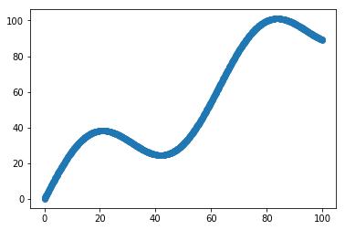

```python
X_train = np.arange(100, step=.1)
Y_train = X_train + 20 * np.sin(X_train/10)
plt.scatter(X_train, Y_train)
```

```python
n_sample = X_train.shape[0]
batch_size = 100
```

```python
X_train = np.reshape(X_train, (n_sample, 1))
Y_train = np.reshape(Y_train, (n_sample, 1))
```

```python
# converting external data (numpy arrays) to tensors
# tf.placeholder for making dummy nodes which are points of entry
X = tf.placeholder(tf.float32, shape = (batch_size, 1))
Y = tf.placeholder(tf.float32, shape = (batch_size, 1))
```

Loss function:  
$J(W,b) = \frac{1}{N} \sum_{i=1}^N (y_i - (Wx_i + b))^2$

```python
# defining variables/tensors
# tf.matmul is equivalent to np.dot
with tf.variable_scope('linear-regression'):
    W = tf.get_variable('weight', (1,1), initializer = tf.random_normal_initializer())
    b = tf.get_variable('bias', (1,), initializer = tf.constant_initializer(0.0))
    yhat = tf.matmul(X, W) + b
    loss = tf.reduce_sum((Y - yhat)**2/n_sample)
```

`tf.train.AdamOptimizer` is a subclass of `tf.train.Optimizer` that defines the API to add Ops to train a model.

```python
opt = tf.train.AdamOptimizer()
# TensorFlow scope is not python scope and Python variable 'loss' is visible.
opt_operation = opt.minimize(loss)
```

```python
# one step gradient descent
with tf.Session() as sess:
    sess.run(tf.initialize_all_variables())
    print(sess.run([opt_operation, loss], feed_dict = {X : X_train[0:100], Y : Y_train[0:100]}))
```

```
WARNING:tensorflow:From /anaconda3/envs/open-ai/lib/python3.6/site-packages/tensorflow/python/util/tf_should_use.py:118: initialize_all_variables (from tensorflow.python.ops.variables) is deprecated and will be removed after 2017-03-02.
Instructions for updating:
Use `tf.global_variables_initializer` instead.
[None, 31.220903]
```

```python
# full gradient descent
with tf.Session() as sess:
    sess.run(tf.initialize_all_variables())
    saver = tf.train.Saver()
    # gradient descent for 500 steps
    for step in range (5001):
        indices = np.random.choice(n_sample, batch_size)
        x_batch, y_batch = X_train[indices], Y_train[indices]
        _, loss_values = sess.run([opt_operation, loss], feed_dict = {X : x_batch, Y : y_batch})
        if step % 1000 == 0:
            print('{0:04d} loss_values: {1:.3f}'.format(step, loss_values))
```

```
0000 loss_values: 258.472
1000 loss_values: 25.350
2000 loss_values: 18.125
3000 loss_values: 18.921
4000 loss_values: 16.919
5000 loss_values: 15.871
```